# GSE148731: Generate toptable for MF2 data

A. Nohturfft

2020-07-10

## Objective:

For dataset GSE148731 generate toptable of fold changes from raw counts deposited in Excel files on GEO.

1. Type-I macrophages, 24-hour data
2. Type-II macrophages, 24-hour data

**Background**:  
Data on GEO cannot be used directly for meta analysis as data processing and data formats are not documented.

**Aims:**  
1. Analyze RNA-seq data using `limma` package.  
2. Save toptable for downstream meta analyses

**Approach:** Start with raw counts and follow [Bioconductor tutorial](https://www.bioconductor.org/help/workflows/RNAseq123/) by Law et al.

```r
.libPaths()
# Clear memory
rm(list=ls(all=TRUE))
# Clear console
cat("\014")
```

```r
(this.script <- rstudioapi::getActiveDocumentContext()$path %>% basename)
```

## Load data

### Load raw counts table and aggregate by gene symbol

Calculate median counts where more than one row exists for the same gene symbol.

```r
data.file <- list.files(pattern=".*MF2.*xlsx$")
data.file
```

[1] “GSE148731_4_MF2_infected_versus_non-infected_24_hours.xlsx”

```r
stopifnot(file.exists(data.file))
```

```r
df <- readxl::read_xlsx(path = data.file, range = "B1:R60449") %>%
  dplyr::select(gene, dplyr::contains("fastq")) %>%
  dplyr::select(gene, !dplyr::contains("scaled")) %>%
  dplyr::mutate(gene = toupper(gene))
names(df)[grep("CTRL", names(df))] <- paste0("Counts.Ctrl.", seq_along(grep("CTRL", names(df))))
names(df)[grep("MEAS", names(df))] <- paste0("Counts.Infected.", seq_along(grep("MEAS", names(df))))
mx <- df %>%
  dplyr::group_by(gene) %>%
  dplyr::summarise(across(starts_with("Counts"), median, na.rm=T), .groups="drop") %>%
  tibble::column_to_rownames(var="gene") %>%
  as.matrix(.) %>%
  .[,order(colnames(.))]
colnames(mx) <- stringr::str_remove(colnames(mx), "Counts\\.")
rm(df)
```

Print first six rows of raw counts matrix:

```r
head(mx) %>%
  knitr::kable(., row.names = T) %>% kableExtra::kable_styling(bootstrap_options = c("striped", "hover"))
```

|  | Ctrl.1 | Ctrl.2 | Ctrl.3 | Infected.1 | Infected.2 | Infected.3 |
| --- | --- | --- | --- | --- | --- | --- |
| 5_8S_RRNA | 0 | 0 | 0 | 0 | 0 | 0 |
| 5S_RRNA | 0 | 0 | 0 | 0 | 0 | 0 |
| 7SK | 0 | 0 | 0 | 0 | 0 | 0 |
| A1BG | 286 | 373 | 578 | 170 | 93 | 184 |
| A1BG-AS1 | 281 | 403 | 591 | 206 | 101 | 248 |
| A1CF | 0 | 0 | 4 | 1 | 1 | 0 |

### Check total counts per sample

```r
# http://haozhu233.github.io/kableExtra/awesome_table_in_html.html
data.frame(Sample=colnames(mx), Total.counts=comma(colSums(mx)), row.names = NULL) %>%
  knitr::kable(.) %>% kableExtra::kable_styling(bootstrap_options = c("striped", "hover"))
```

| Sample | Total.counts |
| --- | --- |
| Ctrl.1 | 14,962,610 |
| Ctrl.2 | 20,888,211 |
| Ctrl.3 | 32,703,138 |
| Infected.1 | 13,199,920 |
| Infected.2 | 7,440,495 |
| Infected.3 | 14,215,932 |

## Analyse raw counts

### Create edgeR::DGEList object

```r
group <- c(rep(c("Ctrl", "Infected"), c(3,3))) %>% as.factor
# group # "Ctrl" "Ctrl" "Ctrl" "Dox"  "Dox"  "Dox"
dgel <- edgeR::DGEList(counts=mx,
                       group=group,
                       genes=rownames(mx))
```

```r
dgel
```

```
An object of class "DGEList"
$counts
          Ctrl.1 Ctrl.2 Ctrl.3 Infected.1 Infected.2 Infected.3
5_8S_RRNA      0      0      0          0          0          0
5S_RRNA        0      0      0          0          0          0
7SK            0      0      0          0          0          0
A1BG         286    373    578        170         93        184
A1BG-AS1     281    403    591        206        101        248
58579 more rows ...

$samples
```

|  | group | lib.size | norm.factors |
| --- | --- | --- | --- |
| Ctrl.1 | Ctrl | 14962610 | 1 |
| Ctrl.2 | Ctrl | 20888211 | 1 |
| Ctrl.3 | Ctrl | 32703138 | 1 |
| Infected.1 | Infected | 13199920 | 1 |
| Infected.2 | Infected | 7440495 | 1 |
| Infected.3 | Infected | 14215932 | 1 |

|  | genes |
| --- | --- |
| 5_8S_RRNA | 5_8S_RRNA |
| 5S_RRNA | 5S_RRNA |
| 7SK | 7SK |
| A1BG | A1BG |
| A1BG-AS1 | A1BG-AS1 |

```
58579 more rows ...
```

### Calculate Counts Per Million (CPM)

> *"For differential expression and related analyses, gene expression is rarely considered at the level of raw counts since libraries sequenced at a greater depth will result in higher counts. Rather, it is common practice to transform raw counts onto a scale that accounts for such library size differences. Popular transformations include counts per million (CPM), log2-counts per million (log-CPM), reads per kilobase of transcript per million (RPKM), and fragments per kilobase of transcript per million (FPKM).*

> In our analyses, CPM and log-CPM transformations are used regularly although they do not account for feature length differences which RPKM and FPKM values do. Whilst RPKM and FPKM values can just as well be used, CPM and log-CPM values can be calculated using a counts matrix alone and will suffice for the type of comparisons we are interested in. Assuming that there are no differences in isoform usage between conditions, differential expression analyses look at gene expression changes between conditions rather than comparing expression across multiple genes or drawing conclusions on absolute levels of expression. In other words, gene lengths remain constant for comparisons of interest and any observed differences are a result of changes in condition rather than changes in gene length."

The formula seems to be: `(raw counts / total counts in sample) x 1e6`

```r
cpm <- edgeR::cpm(dgel)
lcpm.unfiltered <- edgeR::cpm(dgel, log=TRUE)
head(cpm)
```

```
            Ctrl.1   Ctrl.2     Ctrl.3  Infected.1 Infected.2 Infected.3
5_8S_RRNA  0.00000  0.00000  0.0000000  0.00000000  0.0000000    0.00000
5S_RRNA    0.00000  0.00000  0.0000000  0.00000000  0.0000000    0.00000
7SK        0.00000  0.00000  0.0000000  0.00000000  0.0000000    0.00000
A1BG      19.11431 17.85696 17.6741449 12.87886642 12.4991684   12.94322
A1BG-AS1  18.78015 19.29318 18.0716603 15.60615578 13.5743657   17.44522
A1CF       0.00000  0.00000  0.1223124  0.07575804  0.1343997    0.00000
```

Now the total CPM per sample should be the same …

```r
colSums(cpm)
```

```
    Ctrl.1     Ctrl.2     Ctrl.3 Infected.1 Infected.2 Infected.3
     1e+06      1e+06      1e+06      1e+06      1e+06      1e+06
```

### Removing genes that are lowly expressed

> “Using a nominal CPM value of 1 (which is equivalent to a log-CPM value of 0) genes are deemed to be expressed if their expression is above this threshold, and unexpressed otherwise. Genes must be expressed in at least one group (or in at least three samples across the entire experiment) to be kept for downstream analysis.  
> Although any sensible value can be used as the expression cutoff, typically a CPM value of 1 is used in our analyses as it separates expressed genes from unexpressed genes well for most datasets.”

```r
# keep.exprs <- rowSums(cpm>1)>=3
keep.exprs <- rowSums(cpm>1)>=6
dgel.2 <- dgel[keep.exprs,, keep.lib.sizes=FALSE]
lcpm.filtered <- cpm(dgel.2, log=TRUE)
# dim(dgel) # 11823     6
cat("New count of data rows:", comma(nrow(dgel.2$counts)), "<br>\n")
```

New count of data rows: 17,085

### Plot count (CPM) distributions

```r
nsamples <- ncol(dgel.2)
col <- brewer.pal(nsamples, "Paired")
par(mfrow=c(1,2))
# -----------------------------------
# Un-filtered data:
# -----------------------------------
plot(density(lcpm.unfiltered[,1]), col=col[1], lwd=2, ylim=c(0,0.21), las=2, main="A. Raw data", xlab="Log-cpm")
# title(main="A. Raw data", xlab="Log-cpm")
#
abline(v=0, lty=3)
```

```r
for (i in 2:nsamples){
 den <- density(lcpm.unfiltered[,i])
 lines(den$x, den$y, col=col[i], lwd=2)
}
legend("topright", colnames(dgel.2$counts), text.col=col, bty="n")
```

```r
# -----------------------------------
# Filtered data:
# -----------------------------------
plot(density(lcpm.filtered[,1]), col=col[1], lwd=2, ylim=c(0,0.21), las=2, main="B. Filtered data", xlab="Log-cpm")
abline(v=0, lty=3)
```

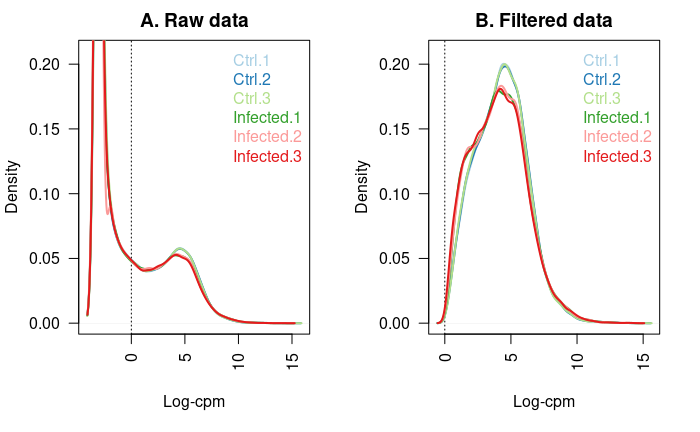

```r
for (i in 2:nsamples){
   den <- density(lcpm.filtered[,i])
   lines(den$x, den$y, col=col[i], lwd=2)
}
legend("topright", colnames(dgel.2$counts), text.col=col, bty="n")
```

```r
rm(nsamples, col, den, lcpm.unfiltered, lcpm.filtered)
```